# Final Model

[GitHub](https://github.com/elenabagnera/CapitalBikesProject)

## Comparing RMSEs of our models

Random forests does better than decision tree and LASSO models in terms of RMSE.

- Decision tree lowest RMSE - 4.25
- Random Forest - 3.82
- LASSO lowest RMSE - 4

### Potential reasons for Random Forests out-performing decision trees and LASSO

Having a group of decision trees creates “randomness” and avoids common weaknesses in predictions based on one decision tree over fitting and excessive correlation between variables. This is because

1. random forest algorithm uses a subset of features as candidates at each split (does not rely on the same set of features: de-correlates individual trees)
2. Each tree uses a random sample from the training dataset as it generates the splits which inserts an aspect of randomness and prevents overfitting

Compared to LASSO regression, Random forests decision trees are great for obtaining non-linear relationships between input features and the target variable.

RF also operates within sample, as opposed to LASSO models which could potentially provide out of sample predictions. In our case, this might be risky because we can not have negative departures, and since departures could go to very high levels in general, we should be careful in analyzing predictions that give very high hourly departure estimation which could be unrealistic. Although we expected LASSO to do a better job in avoiding multicollinearity between our predictors, it is difficult to judge for sure.

## Implementing Random Forest on full training data

```r
lagged_data <- read_csv('lagged_data_3200.csv')
hour_data <- read_csv('hour_data_3200.csv') # Used for graphs

model_data <- lagged_data %>%
  add_predictor_times() %>%
  filter(!is.na(departures) & !is.na(arrivals)) %>%
  # Having real time arrival data would be cheating
  select(-arrivals) %>%
  format_weather()
```

```r
set.seed(28021995)

# create a split object
data_split <- initial_split(model_data, prop = 0.8)

# create the training and testing data
train <- training(x = data_split)
test  <- testing(x = data_split)
```

```r
recipe <-
  recipe(formula = departures ~ ., data = train) %>%
  step_holiday(date, holidays = timeDate::listHolidays("US"), keep_original_cols = FALSE) %>%
  step_nzv(all_predictors())
  # step_BoxCox(all_outcomes()) # Does not run with zero in the values
```

## Model Implementation

min_n left to default.

```r
# Tuning min_n doesn't seem to help
mod <- rand_forest(mtry = 250, trees = 1000) %>%
  set_mode("regression") %>%
  set_engine("ranger")
```

```r
final_wf <- workflow() %>%
  add_recipe(recipe) %>%
  add_model(mod) %>%
  fit(train)
```

## Making Predictions on the Testing Data

```r
p_test <- bind_cols(
  test,
  predict(object = final_wf, new_data = test))
```

Out of sample RMSE: this is smaller than what we got when we ran random forest on the training data with folds.

```r
sqrt(mean((p_test$departures - p_test$.pred)^2))
```

```
## [1] 3.713051
```

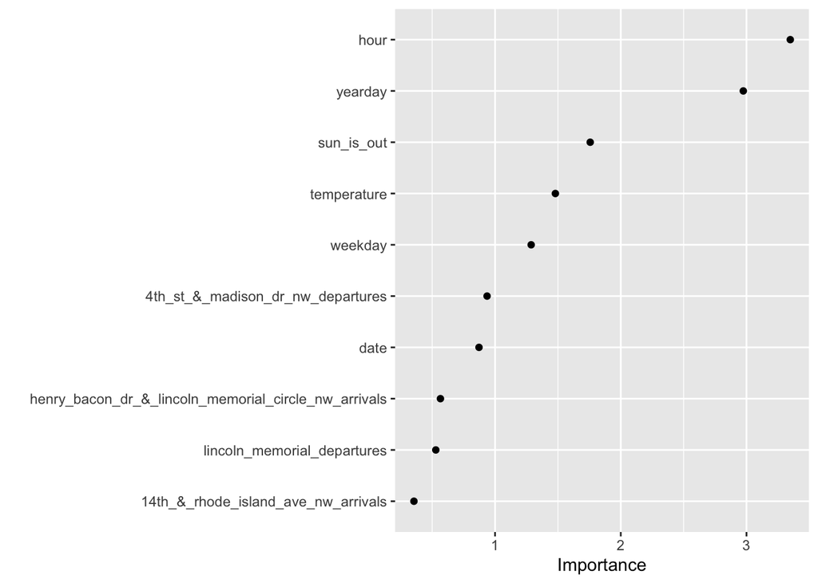

```r
mod %>%
  set_engine("ranger", importance = "permutation") %>%
  fit(departures ~ .,
    data = train
  ) %>%
  vip(geom = "point")
```

Based on the variable importance plot, our most important predictors are:

1. Hour: as expected, the hour has a big influence on predicting departures at Lincoln Memorial Station. We know from the exploration period that there is some hours *(1-6 am)* where departures are nearly non existance, compared to peaking in the evening around *(2 pm)*
2. Year day: It is likely that year day affects departures because it reflects seasons which has many implications, including but not limited to weather changes due to seasons, but also other periods like the summer holidays.
3. Sun: Our results also suggest that departures are associated with sunlight. This is reasonable given that people are more likely to ride bikes duirng daylight. This could also be a redundant variable with hour given too much weight to the time of day.
4. Week day: From earlier data exploration we could see that weekdays have a strong relationship with departures (less departures during weekends). This is a reasonable prediction.
5. 4th Street and Maddison DR. Station departures and arrivals: This suggests that a lot trips go back and forth between Lincoln Memorial Station and 4th Street and Maddison Dr. Station or simply that if that nearby station is receiving a lot of traffic, so too is the Lincoln Memorial. Trips back and forth from near the Smithonian to Lincoln Memorial seem popular among Capital Bikeshare riders.

## Discussion of Results

### Average departures per hour

```r
p_test %>% summarize(mean(departures))
```

```
## # A tibble: 1 × 1
##   `mean(departures)`
##                <dbl>
## 1               3.45
```

The average departures per hour are `3.45`. Therefore an RMSE > 3.45 appears to not be very good. Lets look at the areas where the predictions are poor.

### Top 20 hours of 12431 hours.

```r
p_test %>% arrange(-departures) %>% select(departures) %>% head(20)
```

```
## # A tibble: 20 × 1
##    departures
##         <dbl>
##  1         35
##  2         34
##  3         34
##  4         32
##  5         31
##  6         31
##  7         30
##  8         28
##  9         27
## 10         27
## 11         27
## 12         27
## 13         27
## 14         26
## 15         25
## 16         25
## 17         25
## 18         25
## 19         25
## 20         24
```

### Top 20 Error

Below is our largest error.

- The Error column shows how many `rides / hour` the model missed by for that given hour.
- The departures column shows the actual number of departures
- the .pred column shows what the model predicted
- All other columns (lincoln_memorial_x, weather, temperature, etc are lagged two weeks)

```r
p_test %>%
  mutate(error = abs(.pred - departures)) %>%
  select(year, month, day, hour, weekday, departures, .pred, error, conditions,temperature, cloud_cover, snow, precipitation, lincoln_memorial_departures) %>%
  arrange(-error) %>%
  head(20) %>%
  formattable()
```

| year | month | day | hour | weekday | departures | .pred | error | conditions | temperature | cloud_cover | snow | precipitation | lincoln_memorial_departures |
| --- | --- | --- | --- | --- | --- | --- | --- | --- | --- | --- | --- | --- | --- |
| 2020 | Aug | 30 | 13 | Sun | 34 | 7.442667 | 26.55733 | Good | 71.8 | 62.3 | 0 | 0 | 5 |
| 2021 | Mar | 21 | 15 | Sun | 35 | 8.659767 | 26.34023 | Good | 46.8 | 0.0 | 0 | 0 | 13 |
| 2021 | May | 31 | 11 | Mon | 31 | 5.714333 | 25.28567 | Okay | 68.1 | 79.4 | 0 | 0 | 3 |
| 2021 | Jul | 5 | 13 | Mon | 31 | 6.673350 | 24.32665 | Okay | 86.1 | 81.2 | 0 | 0 | 11 |
| 2021 | Apr | 4 | 19 | Sun | 32 | 7.880283 | 24.11972 | Good | 57.8 | 24.5 | 0 | 0 | 3 |
| 2021 | Mar | 27 | 11 | Sat | 30 | 9.378850 | 20.62115 | Good | 51.9 | 44.6 | 0 | 0 | 9 |
| 2021 | May | 30 | 17 | Sun | 27 | 7.382033 | 19.61797 | Okay | 63.1 | 90.4 | 0 | 0 | 8 |
| 2020 | Aug | 9 | 13 | Sun | 28 | 8.677983 | 19.32202 | Good | 92.8 | 45.8 | 0 | 0 | 10 |
| 2020 | Jun | 27 | 15 | Sat | 34 | 15.585867 | 18.41413 | Good | 79.0 | 45.8 | 0 | 0 | 28 |
| 2021 | May | 28 | 13 | Fri | 26 | 7.839417 | 18.16058 | Okay | 69.0 | 83.3 | 0 | 0 | 10 |
| 2021 | May | 29 | 14 | Sat | 0 | 18.150100 | 18.15010 | Good | 76.6 | 27.8 | 0 | 0 | 14 |
| 2021 | Mar | 30 | 18 | Tue | 27 | 9.084783 | 17.91522 | Okay | 44.7 | 100.0 | 0 | 0 | 0 |
| 2021 | Jan | 16 | 14 | Sat | 0 | 17.539183 | 17.53918 | Okay | 56.9 | 79.4 | 0 | 0 | 12 |
| 2020 | May | 25 | 11 | Mon | 20 | 3.313517 | 16.68648 | Okay | 57.3 | 81.2 | 0 | 0 | 1 |
| 2020 | Sep | 6 | 17 | Sun | 27 | 10.348150 | 16.65185 | Good | 88.0 | 33.1 | 0 | 0 | 14 |
| 2021 | Jul | 28 | 12 | Wed | 21 | 5.183333 | 15.81667 | Good | 89.9 | 44.6 | 0 | 0 | 2 |
| 2021 | May | 31 | 18 | Mon | 24 | 8.348300 | 15.65170 | Okay | 73.8 | 79.4 | 0 | 0 | 5 |
| 2021 | Apr | 24 | 15 | Sat | 4 | 18.540817 | 14.54082 | Okay | 71.1 | 79.4 | 0 | 0 | 36 |
| 2021 | May | 31 | 9 | Mon | 16 | 1.837733 | 14.16227 | Good | 63.0 | 44.6 | 0 | 0 | 4 |
| 2020 | Aug | 30 | 14 | Sun | 24 | 9.965150 | 14.03485 | Okay | 73.0 | 91.4 | 0 | 0 | 9 |

### Best guesses

The model predicts very well at 2-5 AM.

```r
p_test %>%
  mutate(error = abs(.pred - departures)) %>%
  select(year, month, day, hour, weekday, departures, .pred, error, conditions,temperature, cloud_cover, snow, precipitation, lincoln_memorial_departures)  %>%
  arrange(error) %>%
  head(20) %>%
  formattable()
```

| year | month | day | hour | weekday | departures | .pred | error | conditions | temperature | cloud_cover | snow | precipitation | lincoln_memorial_departures |
| --- | --- | --- | --- | --- | --- | --- | --- | --- | --- | --- | --- | --- | --- |
| 2020 | May | 16 | 3 | Sat | 0 | 0 | 0 | Good | 53.9 | 0.0 | 0 | 0.00 | 0 |
| 2020 | May | 19 | 3 | Tue | 0 | 0 | 0 | Okay | 52.9 | 92.9 | 0 | 0.00 | 0 |
| 2020 | May | 23 | 5 | Sat | 0 | 0 | 0 | Good | 37.9 | 0.0 | 0 | 0.00 | 0 |
| 2020 | May | 25 | 4 | Mon | 0 | 0 | 0 | Okay | 51.5 | 80.5 | 0 | 0.00 | 0 |
| 2020 | May | 28 | 3 | Thu | 0 | 0 | 0 | Good | 52.3 | 24.5 | 0 | 0.00 | 0 |
| 2020 | May | 29 | 4 | Fri | 0 | 0 | 0 | Good | 63.0 | 63.0 | 0 | 0.00 | 0 |
| 2020 | Jun | 17 | 2 | Wed | 0 | 0 | 0 | Okay | 68.7 | 89.2 | 0 | 0.00 | 0 |
| 2020 | Jun | 26 | 4 | Fri | 0 | 0 | 0 | Okay | 73.0 | 90.2 | 0 | 0.00 | 0 |
| 2020 | Aug | 4 | 4 | Tue | 0 | 0 | 0 | Good | 78.7 | 37.5 | 0 | 0.00 | 0 |
| 2020 | Sep | 10 | 3 | Thu | 0 | 0 | 0 | Okay | 74.6 | 79.4 | 0 | 0.00 | 0 |
| 2020 | Sep | 19 | 5 | Sat | 0 | 0 | 0 | Good | 65.8 | 44.6 | 0 | 0.00 | 0 |
| 2020 | Sep | 24 | 3 | Thu | 0 | 0 | 0 | Okay | 75.7 | 76.9 | 0 | 0.00 | 0 |
| 2020 | Oct | 3 | 4 | Sat | 0 | 0 | 0 | Good | 52.8 | 0.0 | 0 | 0.00 | 0 |
| 2020 | Oct | 6 | 3 | Tue | 0 | 0 | 0 | Good | 50.4 | 0.0 | 0 | 0.00 | 0 |
| 2020 | Oct | 9 | 3 | Fri | 0 | 0 | 0 | Okay | 63.6 | 79.4 | 0 | 0.00 | 0 |
| 2020 | Oct | 10 | 3 | Sat | 0 | 0 | 0 | Bad | 62.8 | 91.7 | 0 | 0.06 | 0 |
| 2020 | Oct | 14 | 3 | Wed | 0 | 0 | 0 | Bad | 56.8 | 63.5 | 0 | 0.04 | 0 |
| 2020 | Oct | 15 | 4 | Thu | 0 | 0 | 0 | Good | 58.9 | 0.0 | 0 | 0.00 | 0 |
| 2020 | Oct | 21 | 3 | Wed | 0 | 0 | 0 | Good | 57.4 | 24.5 | 0 | 0.00 | 0 |
| 2020 | Nov | 8 | 5 | Sun | 0 | 0 | 0 | Bad | 50.0 | 95.5 | 0 | 0.02 | 0 |

### Best guesses with more 5 departures

```r
p_test %>%
  mutate(error = abs(.pred - departures)) %>%
  filter(departures > 5) %>%
  select(year, month, day, hour, weekday, departures, .pred, error, conditions,temperature, cloud_cover, snow, precipitation, lincoln_memorial_departures)  %>%
  arrange(error) %>%
  head(20) %>%
  formattable()
```

| year | month | day | hour | weekday | departures | .pred | error | conditions | temperature | cloud_cover | snow | precipitation | lincoln_memorial_departures |
| --- | --- | --- | --- | --- | --- | --- | --- | --- | --- | --- | --- | --- | --- |
| 2021 | Jun | 5 | 17 | Sat | 13 | 13.027167 | 0.02716667 | Okay | 88.9 | 89.2 | 0 | 0 | 3 |
| 2021 | Mar | 25 | 14 | Thu | 7 | 6.962017 | 0.03798333 | Good | 75.1 | 24.5 | 0 | 0 | 9 |
| 2020 | Jul | 22 | 21 | Wed | 6 | 6.040200 | 0.04020000 | Good | 81.6 | 33.1 | 0 | 0 | 1 |
| 2020 | Jun | 7 | 14 | Sun | 12 | 11.948783 | 0.05121667 | Okay | 65.7 | 100.0 | 0 | 0 | 9 |
| 2021 | Aug | 4 | 21 | Wed | 7 | 7.060533 | 0.06053333 | Good | 79.6 | 44.6 | 0 | 0 | 21 |
| 2021 | Jul | 12 | 13 | Mon | 7 | 6.939083 | 0.06091667 | Good | 88.1 | 47.9 | 0 | 0 | 2 |
| 2021 | Jul | 22 | 17 | Thu | 7 | 7.062667 | 0.06266667 | Good | 82.8 | 65.1 | 0 | 0 | 7 |
| 2020 | Oct | 8 | 18 | Thu | 8 | 7.928500 | 0.07150000 | Good | 69.9 | 66.1 | 0 | 0 | 3 |
| 2020 | Nov | 10 | 18 | Tue | 6 | 6.074750 | 0.07475000 | Okay | 64.0 | 99.8 | 0 | 0 | 10 |
| 2021 | Sep | 19 | 14 | Sun | 14 | 14.076283 | 0.07628333 | Okay | 77.1 | 83.8 | 0 | 0 | 19 |
| 2021 | Aug | 12 | 19 | Thu | 7 | 7.086133 | 0.08613333 | Okay | 82.6 | 84.8 | 0 | 0 | 6 |
| 2020 | Jun | 11 | 20 | Thu | 6 | 6.092450 | 0.09245000 | Good | 75.8 | 52.4 | 0 | 0 | 5 |
| 2021 | Jun | 18 | 21 | Fri | 7 | 6.896517 | 0.10348333 | Good | 76.8 | 26.9 | 0 | 0 | 2 |
| 2020 | Jul | 28 | 18 | Tue | 8 | 7.893217 | 0.10678333 | Good | 88.9 | 33.1 | 0 | 0 | 2 |
| 2020 | Jul | 24 | 16 | Fri | 7 | 6.873000 | 0.12700000 | Good | 88.1 | 64.8 | 0 | 0 | 4 |
| 2021 | Jun | 16 | 14 | Wed | 7 | 6.868583 | 0.13141667 | Okay | 80.7 | 85.1 | 0 | 0 | 6 |
| 2020 | Aug | 9 | 19 | Sun | 8 | 7.862200 | 0.13780000 | Good | 92.8 | 33.1 | 0 | 0 | 4 |
| 2020 | Aug | 15 | 18 | Sat | 11 | 10.838517 | 0.16148333 | Okay | 85.9 | 82.3 | 0 | 0 | 19 |
| 2020 | Sep | 21 | 13 | Mon | 11 | 11.174433 | 0.17443333 | Good | 80.1 | 24.5 | 0 | 0 | 20 |
| 2021 | Jul | 19 | 20 | Mon | 8 | 7.809567 | 0.19043333 | Good | 83.7 | 44.6 | 0 | 0 | 6 |

### Worst guessing with low departures - why?

We decided to investigate poor guesses with low actual departures. We realized a large issue with our modeling that does not effect other prediction models as much - weather. Weather will highly affect if a person rides a bike. And our model has no way of knowing the *actual* weather on the hour of the ride. It only knows the lagged weather.

Below shows the worst weather. They happen to be during high volume hours (2 pm is the busiest), good lagged weather, and low actual departures.

```r
p_test %>%
  mutate(error = abs(.pred - departures)) %>%
  filter(departures < 5) %>%
  select(year, month, day, hour, weekday, departures, .pred, error, conditions,temperature, cloud_cover, snow, precipitation, lincoln_memorial_departures)  %>%
  arrange(-error) %>%
  head(20) %>%
  formattable()
```

| year | month | day | hour | weekday | departures | .pred | error | conditions | temperature | cloud_cover | snow | precipitation | lincoln_memorial_departures |
| --- | --- | --- | --- | --- | --- | --- | --- | --- | --- | --- | --- | --- | --- |
| 2021 | May | 29 | 14 | Sat | 0 | 18.150100 | 18.150100 | Good | 76.6 | 27.8 | 0 | 0 | 14 |
| 2021 | Jan | 16 | 14 | Sat | 0 | 17.539183 | 17.539183 | Okay | 56.9 | 79.4 | 0 | 0 | 12 |
| 2021 | Apr | 24 | 15 | Sat | 4 | 18.540817 | 14.540817 | Okay | 71.1 | 79.4 | 0 | 0 | 36 |
| 2021 | Aug | 14 | 15 | Sat | 3 | 16.586233 | 13.586233 | Okay | 80.0 | 81.2 | 0 | 0 | 13 |
| 2020 | Jun | 28 | 14 | Sun | 2 | 14.771517 | 12.771517 | Good | 75.5 | 26.3 | 0 | 0 | 13 |
| 2021 | Apr | 18 | 18 | Sun | 2 | 14.740333 | 12.740333 | Good | 71.9 | 24.5 | 0 | 0 | 22 |
| 2021 | Aug | 1 | 14 | Sun | 1 | 13.374050 | 12.374050 | Okay | 81.1 | 96.9 | 0 | 0 | 11 |
| 2021 | Jul | 4 | 12 | Sun | 0 | 12.108883 | 12.108883 | Okay | 84.9 | 79.4 | 0 | 0 | 10 |
| 2021 | Sep | 21 | 16 | Tue | 1 | 12.375350 | 11.375350 | Okay | 85.8 | 79.4 | 0 | 0 | 15 |
| 2021 | Aug | 29 | 17 | Sun | 0 | 10.846417 | 10.846417 | Okay | 82.6 | 100.0 | 0 | 0 | 9 |
| 2020 | Nov | 7 | 18 | Sat | 1 | 11.680450 | 10.680450 | Okay | 69.2 | 97.2 | 0 | 0 | 11 |
| 2020 | Jun | 8 | 13 | Mon | 0 | 10.479267 | 10.479267 | Good | 71.6 | 72.6 | 0 | 0 | 16 |
| 2021 | Apr | 25 | 11 | Sun | 1 | 11.289800 | 10.289800 | Good | 73.1 | 44.6 | 0 | 0 | 9 |
| 2020 | Sep | 13 | 15 | Sun | 4 | 14.266583 | 10.266583 | Okay | 81.9 | 81.5 | 0 | 0 | 20 |
| 2021 | Apr | 13 | 15 | Tue | 1 | 10.814067 | 9.814067 | Good | 68.0 | 0.0 | 0 | 0 | 24 |
| 2021 | Apr | 18 | 19 | Sun | 2 | 11.661317 | 9.661317 | Good | 70.9 | 0.0 | 0 | 0 | 32 |
| 2020 | Oct | 11 | 17 | Sun | 2 | 11.493400 | 9.493400 | Okay | 74.9 | 89.2 | 0 | 0 | 5 |
| 2021 | Jul | 2 | 11 | Fri | 0 | 9.462550 | 9.462550 | Good | 77.0 | 24.5 | 0 | 0 | 15 |
| 2021 | Jul | 8 | 20 | Thu | 0 | 8.968033 | 8.968033 | Good | 74.5 | 24.5 | 0 | 0 | 9 |
| 2020 | Oct | 11 | 18 | Sun | 0 | 8.944567 | 8.944567 | Okay | 73.9 | 83.8 | 0 | 0 | 12 |

### Worst guesses with low departures and actual weather

The data below rejoins the predictions with the actual weather. The data below is *not* lagged.

```r
p_test_no_wx <- p_test %>%
    mutate(error = abs(.pred - departures)) %>%
  select(year, month, day, hour, weekday, departures, .pred, error, lincoln_memorial_departures)

hour_data_wx <- hour_data %>%
  select(year, month, day, hour, conditions,temperature, cloud_cover, precipitation, wind_speed, heat_index, wind_chill)

left_join(p_test_no_wx, hour_data_wx, on=c(year, month, day, hour)) %>%
  filter(departures < 5) %>%
  arrange(-error) %>%
  head(20) %>%
  formattable()
```

| year | month | day | hour | weekday | departures | .pred | error | lincoln_memorial_departures | conditions | temperature | cloud_cover | precipitation | wind_speed | heat_index | wind_chill |
| --- | --- | --- | --- | --- | --- | --- | --- | --- | --- | --- | --- | --- | --- | --- | --- |
| 2021 | May | 29 | 14 | Sat | 0 | 18.150100 | 18.150100 | 14 | Rain, Overcast | 53.1 | 100.0 | 0.01 | 16.1 | NA | NA |
| 2021 | Jan | 16 | 14 | Sat | 0 | 17.539183 | 17.539183 | 12 | Overcast | 46.9 | 83.6 | 0.00 | 10.2 | NA | 42.1 |
| 2021 | Apr | 24 | 15 | Sat | 4 | 18.540817 | 14.540817 | 36 | Overcast | 62.9 | 92.1 | 0.00 | 9.9 | NA | NA |
| 2021 | Aug | 14 | 15 | Sat | 3 | 16.586233 | 13.586233 | 13 | Partially cloudy | 91.8 | 64.0 | 0.00 | 7.7 | 98.6 | NA |
| 2020 | Jun | 28 | 14 | Sun | 2 | 14.771517 | 12.771517 | 13 | Partially cloudy | 89.0 | 65.4 | 0.00 | 10.6 | 92.7 | NA |
| 2021 | Apr | 18 | 18 | Sun | 2 | 14.740333 | 12.740333 | 22 | Overcast | 62.9 | 89.2 | 0.00 | 7.1 | NA | NA |
| 2021 | Aug | 1 | 14 | Sun | 1 | 13.374050 | 12.374050 | 11 | Rain, Overcast | 74.2 | 99.5 | 0.02 | 6.6 | NA | NA |
| 2021 | Jul | 4 | 12 | Sun | 0 | 12.108883 | 12.108883 | 10 | Overcast | 82.8 | 79.4 | 0.00 | 5.0 | 82.8 | NA |
| 2021 | Sep | 21 | 16 | Tue | 1 | 12.375350 | 11.375350 | 15 | Overcast | 80.0 | 93.1 | 0.00 | 12.4 | 81.9 | NA |
| 2021 | Aug | 29 | 17 | Sun | 0 | 10.846417 | 10.846417 | 9 | Overcast | 82.9 | 98.8 | 0.00 | 0.1 | 86.6 | NA |
| 2020 | Nov | 7 | 18 | Sat | 1 | 11.680450 | 10.680450 | 11 | Clear | 65.0 | 0.0 | 0.00 | 6.2 | NA | NA |
| 2020 | Jun | 8 | 13 | Mon | 0 | 10.479267 | 10.479267 | 16 | Partially cloudy | 77.0 | 26.4 | 0.00 | 5.8 | NA | NA |
| 2021 | Apr | 25 | 11 | Sun | 1 | 11.289800 | 10.289800 | 9 | Overcast | 56.8 | 94.3 | 0.00 | 9.6 | NA | NA |
| 2020 | Sep | 13 | 15 | Sun | 4 | 14.266583 | 10.266583 | 20 | Partially cloudy | 80.0 | 44.6 | 0.00 | 11.1 | 82.2 | NA |
| 2021 | Apr | 13 | 15 | Tue | 1 | 10.814067 | 9.814067 | 24 | Overcast | 64.0 | 85.3 | 0.00 | 9.0 | NA | NA |
| 2021 | Apr | 18 | 19 | Sun | 2 | 11.661317 | 9.661317 | 32 | Overcast | 62.1 | 84.9 | 0.00 | 7.9 | NA | NA |
| 2020 | Oct | 11 | 17 | Sun | 2 | 11.493400 | 9.493400 | 5 | Rain, Overcast | 69.0 | 99.0 | 0.03 | 6.3 | NA | NA |
| 2021 | Jul | 2 | 11 | Fri | 0 | 9.462550 | 9.462550 | 15 | Overcast | 73.0 | 97.2 | 0.00 | 10.9 | NA | NA |
| 2021 | Jul | 8 | 20 | Thu | 0 | 8.968033 | 8.968033 | 9 | Rain, Overcast | 73.0 | 95.1 | 0.06 | 3.4 | NA | NA |
| 2020 | Oct | 11 | 18 | Sun | 0 | 8.944567 | 8.944567 | 12 | Rain, Overcast | 67.9 | 97.4 | 0.02 | 10.9 | NA | NA |

```r
p_test %>% summarize(mean(wind_speed))
```

```
## # A tibble: 1 × 1
##   `mean(wind_speed)`
##                <dbl>
## 1               7.99
```

### Can we predict Lincoln Memorial will be empty?

The initial goal of this project was to predict when a station would be empty. However, the data does not support knowing the actual number of spots available at a station. We were curious if the model would predict lower values for departures at times the station would likely be empty. Below is a high volume day.

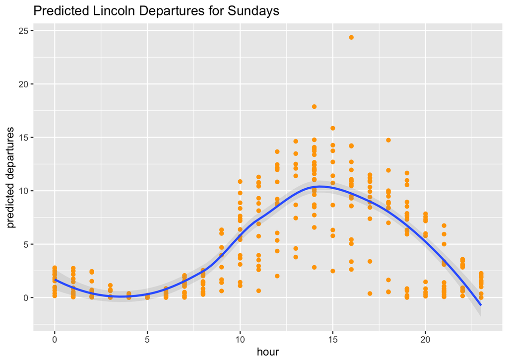

```r
p_test %>%
  filter(weekday == "Sun") %>%
  ggplot(aes(x = hour, y = .pred))+
  geom_point(color = "orange") +
  geom_smooth(alpha=0.2) +
  labs(title = "Predicted Lincoln Departures for Sundays",
     y = "predicted departures")
```

It does not appear easy to predict for the lincoln_memorial station. But that station is also not empty very often.

### Why the variance for a given hour on a Sunday?

We tested if perhaps the low values were actually predicting an empty station. We focused on 2 PM on Sunday, which is one of the highest demand times.

After graphing the results over many of the predictors we found that the departures and arrivals, two weeks lagged, for 4th St and Madison / the Lincoln Memorial were strong correlators to the variance in a given hour. Below is the graph showing that.

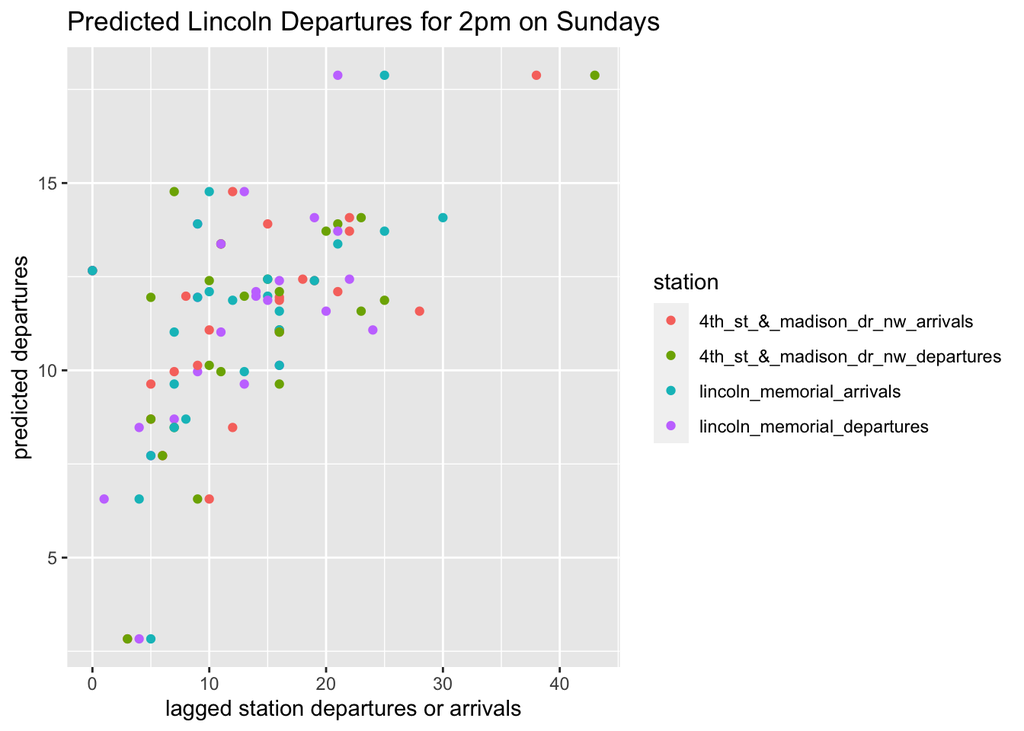

```r
p_test %>%
  filter(weekday == "Sun", hour == 14) %>%
  select(`4th_st_&_madison_dr_nw_arrivals`, `4th_st_&_madison_dr_nw_departures`, `lincoln_memorial_departures`, lincoln_memorial_arrivals, .pred) %>%
  pivot_longer(1:4, names_to = "station", values_to="value") %>%
  ggplot(aes(x = value, y = .pred, color=station))+
  geom_point() +
  labs(title = "Predicted Lincoln Departures for 2pm on Sundays",
    y = "predicted departures",
    x = "lagged station departures or arrivals")
```

### Filtering out the Daylight Savings Time data point and showing the trends

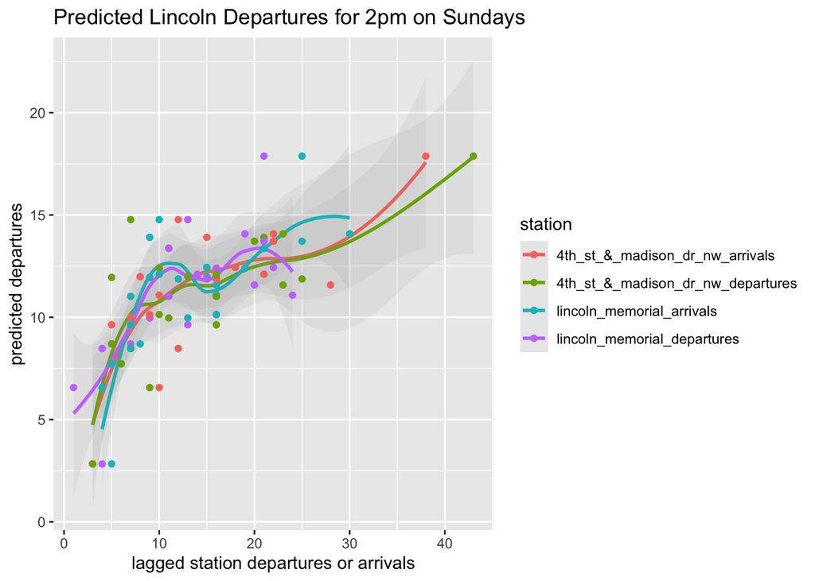

```r
# Only having one data point for certain times of the year hurts
# That one high datapoint is daylight savings time....
# only 23 hours in that day
p_test %>%
  filter(weekday == "Sun", hour == 14) %>%
  select(`4th_st_&_madison_dr_nw_arrivals`, `4th_st_&_madison_dr_nw_departures`, `lincoln_memorial_departures`, lincoln_memorial_arrivals, .pred) %>%
  pivot_longer(1:4, names_to = "station", values_to="value") %>%
  filter(value >= 1) %>%
  ggplot(aes(x = value, y = .pred, color=station))+
  geom_smooth(aes(x = value, y = .pred, color=station), alpha=0.1)+
  geom_point() +
  labs(title = "Predicted Lincoln Departures for 2pm on Sundays",
    y = "predicted departures",
    x = "lagged station departures or arrivals")
```

Having two or more years would likely have helped whic did not have a large change due to COVID. Many of the large variances were Oct-March, where we have a single data point since our data covers approximately 17 months.

## High Supply

To investigate more on if we could predict if a station would be empty or full we analyzed a very high supply station and a very high demand station. Below sithe high supply.

```r
cbs_data <- read_files('data/')

data <- sep_departures_from_arrivals(cbs_data) %>%
  filter(!is.na(station)) # Remove electric bikes not going to / from a station

filtered_data <- filter_by_distance(data, from_station = 'georgetown_harbor_/_30th_st_nw', distance_m = 1600)

hour_data <- get_station_hourly(filtered_data) %>%
  get_historic_weather() %>%
  add_sun_is_out()

lagged_data <- setup_for_time_prediction(hour_data, station_name = "georgetown_harbor_/_30th_st_nw")

model_data <- lagged_data %>%
  add_predictor_times() %>%
  filter(!is.na(departures) & !is.na(arrivals)) %>%
  select(-departures) %>%
  format_weather()
```

```r
# create a split object
data_split <- initial_split(model_data, prop = 0.8)

# create the training and testing data
train <- training(x = data_split)
test  <- testing(x = data_split)

mod <- rand_forest(mtry = 250, trees = 1000) %>%
  set_mode("regression") %>%
  set_engine("ranger")

recipe <-
  recipe(formula = arrivals ~ ., data = train) %>%
  step_holiday(date, holidays = timeDate::listHolidays("US"), keep_original_cols = FALSE) %>%
  step_nzv(all_predictors())
```

```r
final_wf <- workflow() %>%
  add_recipe(recipe) %>%
  add_model(mod) %>%
  fit(train)
p_test <- bind_cols(
  test,
  predict(object = final_wf, new_data = test))
```

We are guessing that the stepping functions are causing the reduction in predictors.

## High Supply Results

Out of sample RMSE

```r
sqrt(mean((p_test$arrivals - p_test$.pred)^2))
```

```
## [1] 2.245656
```

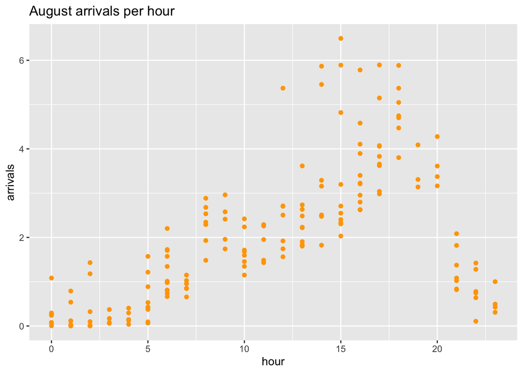

```r
p_test %>%
  filter(month == "Aug" && year == 2021) %>%
  ggplot(aes(x = hour, y = .pred))+
  geom_point(color = "orange")+
  labs(title = "August arrivals per hour",
     y = "arrivals")
```

## High Demand

```r
filtered_data <- filter_by_distance(data, from_station = '39th_&_calvert_st_nw_/_stoddert', distance_m = 1600)

hour_data <- get_station_hourly(filtered_data) %>%
  get_historic_weather() %>%
  add_sun_is_out()

lagged_data <- setup_for_time_prediction(hour_data, station_name = "39th_&_calvert_st_nw_/_stoddert")

model_data <- lagged_data %>%
  add_predictor_times() %>%
  filter(!is.na(departures) & !is.na(arrivals)) %>%
  select(-arrivals) %>%
  format_weather()
```

```r
# create a split object
data_split <- initial_split(model_data, prop = 0.8)

# create the training and testing data
train <- training(x = data_split)
test  <- testing(x = data_split)

mod <- rand_forest(mtry = 250, trees = 1000) %>%
  set_mode("regression") %>%
  set_engine("ranger")

recipe <-
  recipe(formula = departures ~ ., data = train) %>%
  step_holiday(date, holidays = timeDate::listHolidays("US"), keep_original_cols = FALSE) %>%
  step_nzv(all_predictors())
```

```r
final_wf <- workflow() %>%
  add_recipe(recipe) %>%
  add_model(mod) %>%
  fit(train)
p_test <- bind_cols(
  test,
  predict(object = final_wf, new_data = test))
```

We are guessing that the stepping functions are causing the reduction in predictors.

## Results

### Out of sample RMSE

```r
sqrt(mean((p_test$departures - p_test$.pred)^2))
```

```
## [1] 1.147436
```

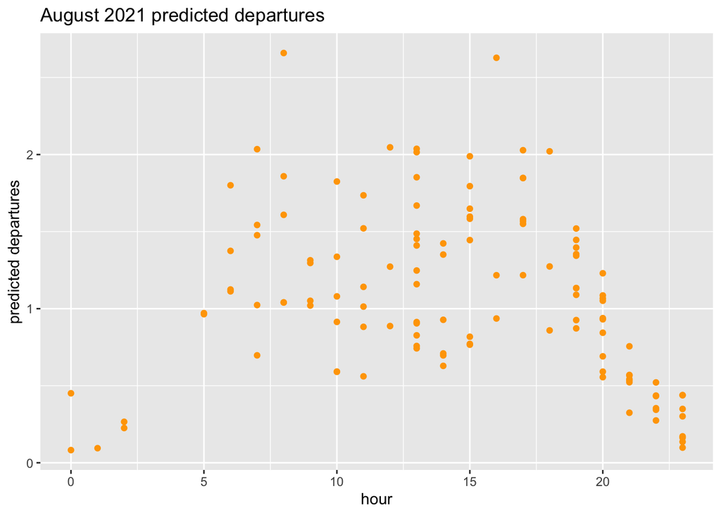

```r
p_test %>%
  filter(month == "Aug" && year == 2021) %>%
  ggplot(aes(x = hour, y = .pred))+
  geom_point(color = "orange") +
  labs(title = "August 2021 predicted departures",
    y = "predicted departures",
    x = "hour")
```

The graph below is an attempt to compare the predicted value vs the overall rides going on in the city. The goal would be that if the overall rides in the city were high, and our predictions were low, perhaps at those times the station was empty. We filter out rows where all predictors are zero, both to avoid dividing by zero, thus getting results of infinity, and because this station also had zero rides at that hour (lagged two weeks). This is a very high demand bike station that should be above the average. It could be that the low predictions relative to volume show a likely empty station time and the high predictions show a non-empty station. This would require further analysis and actual empty status from the real-time data API.

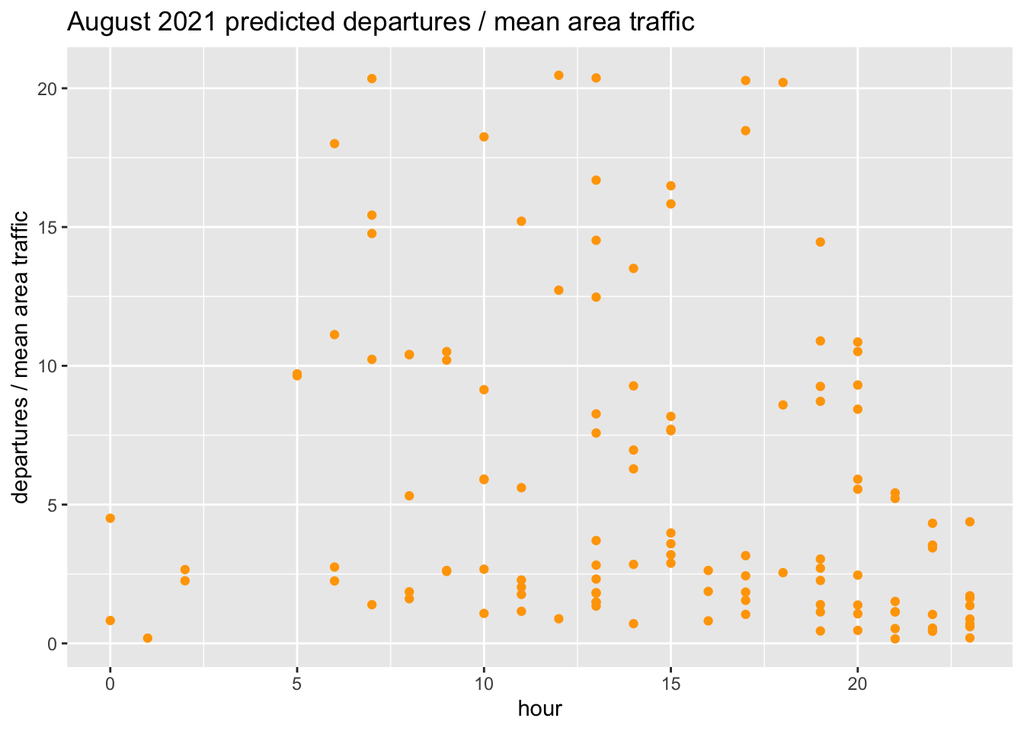

```r
p_test %>%
  mutate(mean = max(mean( `34th_st_&_wisconsin_ave_nw_arrivals`:`connecticut_ave_&_mckinley_st_nw_arrivals`),0.1)) %>%
  filter(mean != 0) %>%
  mutate(pred_div_average = .pred / mean) %>%
  filter(month == "Aug" && year == 2021) %>%
  ggplot(aes(x = hour, y = pred_div_average))+
  geom_point(color = "orange") +
  labs(title = "August 2021 predicted departures / mean area traffic",
    y = "departures / mean area traffic",
    x = "hour")
```

### Takeaways

- The dependent variable is very sensitive to certain real word conditions such as weather. This dataset relies only on lagged data which has no way to know the actual weather when making the prediction. To increase accuracy we would need to use weather predictions which will only be so accurate.
- Simply having one data point for two week lagged data strongly influenced the predictions for nearby stations. If two weeks ago happened to have under-average volume, it is likely our model will under-predict. Therefore, it may be useful to filter stations to a closer distance and use multiple historical data for each station. Perhaps two year, one year, and two weeks.

### Ideas for future improvements

- Transform the dependent variable since this didn’t seem to work for us
- Scrape real time data to get station status. We could take the information from the graph above and create a new is_empty prediction then compare that to the truth data from the API
- Try xgboost. This is an algorithm also based on trees but unlike random forest, it always gives more importance to functional space when reducing the cost of a model, while random forest hones in more on hyper-parameters
- Account for the pandemic somehow (for example over the summer 2020 when there was a curfew) since this could have skewed our projections
- Try a version where we first implement a random forest model to predict a binary variable of whether bikes are departing or not. Then use the predictions to create a new variable and estimate a second random forest model that uses that variable as a predictor
- Instead of using RMSE, we could use a range of error that we envision for our project (eg. we can aim at always having 3 bikes at a station– and hence our prediction would essentially be whether or not we have 3 bikes!)